# STOR 455 Exam #1

## Name: Ted Henson

### Directions:

When you complete the exam:

1. Save the notebook (and create an html file)
2. View the html file of your exam in a web browser to verfiy all is there
3. Upload your html file to Sakai under Assignments/Exam #1

### Question 1

The Game_Data dataset contains a list of video games with sales greater than 100,000 copies. It was generated by scrapes of vgchartz.com and Metacritic. The variables included are:

| Variables | Descriptions |
| --- | --- |
| name | The game’s name |
| platform | Platform of the games release (i.e. PC,PS4, etc.) |
| global_sales | Total worldwide sales in millions of dollars |
| critic_score | Aggregate score compiled by Metacritic staff |
| critic_count | The number of critics who gave the critic_score |
| user_score | Score by Metacritic’s subscribers |
| user_count | Number of users who gave the user_score |

Game_Data contains many blank values. A cleaned version of this data set, which omits the cases containing blank values is created in the R chunk below. You should use the Game_Data_Cleaner data set for this problem!!!

**Run the R chunk below after importing the Game_Data datset**

```r
library(tibble)
library(readr)

library(leaps)
library(mosaic)
library(Stat2Data)
library(readr)


ShowSubsets=function(regout){
  z=summary(regout)
  q=as.data.frame(z$outmat)
  q$Rsq=round(z$rsq*100,2)
  q$adjRsq=round(z$adjr2*100,2)
  q$Cp=round(z$cp,2)
  return(q)
}


# ANOVA for Regression - formatted for whole model
# Argument: model - an lm model

anova455=function(model){
  numpred=model$rank-1
  dferror=df.residual(model)
  dfmodel=numpred
  dftotal=dfmodel+dferror
  sse=sum(model$residual^2)
  ssmodel=sum(model$effects[2:(numpred+1)]^2)
  sstotal=ssmodel+sse
  msmodel=ssmodel/dfmodel
  mse=sse/dferror
  fstat=msmodel/mse
  pvalue=1-pf(fstat,dfmodel,dferror)
  df=c(dfmodel,dferror,dftotal)
  ss=c(ssmodel,sse,sstotal)
  ms=c(msmodel,mse,0)
  f=c(fstat,0,0)
  p=c(pvalue,0,0)
  table=data.frame(df,ss,ms,f,p)
  table[2,4:5]=NA
  table[3,3:5]=NA

  colnames(table)=c("Df","Sum Sq","Mean Sq","F value","P(>F)")
  row.names(table)=c("Model","Error","Total")
  class(table)=c("anova","data.frame")
  structure(table,
            heading=c("ANOVA Table",
                      paste("Model:",
                            formula(model)[2],
                            formula(model)[1],
                            formula(model)[3],"\n")
            )
  )
}

#run the code below to acivate a VIF function
# for multiple regression models

vif<- function(model, ...) {
  V <- summary(model)$cov.unscaled
  Vi <- crossprod(model.matrix(model))
  nam <- names(coef(model))
  if(k <- match("(Intercept)", nam, nomatch = F)) {
    v1 <- diag(V)[-k]
    v2 <- (diag(Vi)[-k] - Vi[k, -k]^2/Vi[k,k])
    nam <- nam[-k]
  } else {
    v1 <- diag(V)
    v2 <- diag(Vi)
    warning("No intercept term detected.  Results may
surprise.")
  }
  structure(v1*v2, names = nam)
}



library(readr)
gamedata <- read_csv("Game_Data.csv")
Game_Data_Cleaner = na.omit(gamedata)
head(Game_Data_Cleaner)
```

| name | platform | global_sales | critic_score | critic_count | user_score | user_count |
| --- | --- | --- | --- | --- | --- | --- |
| [Prototype] | X360 | 1.27 | 78 | 83 | 7.9 | 327 |
| [Prototype] | PS3 | 1.19 | 79 | 53 | 7.8 | 271 |
| 2010 FIFA World Cup South Africa | PS3 | 1.16 | 82 | 56 | 7.8 | 43 |
| 2010 FIFA World Cup South Africa | X360 | 0.82 | 83 | 61 | 8.2 | 49 |
| 2010 FIFA World Cup South Africa | PSP | 0.42 | 69 | 11 | 8.8 | 6 |
| 2010 FIFA World Cup South Africa | Wii | 0.40 | 70 | 19 | 6.3 | 9 |

#### Part A

Construct a simple linear regression model using critic_score to predict global_sales. Plot the data and the regression line on the same axes. You do **not** need to comment on the effectiveness of the model or examine the residuals.

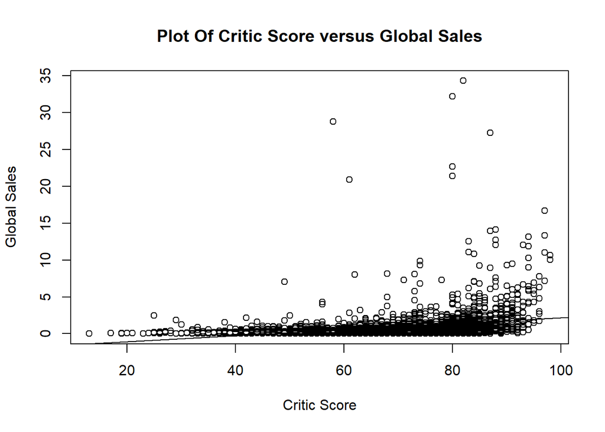

```r
linear <- lm(global_sales ~ critic_score, data = Game_Data_Cleaner)
plot(x = Game_Data_Cleaner$critic_score, y = Game_Data_Cleaner$global_sales, xlab = 'Critic Score', ylab = 'Global Sales', main = 'Plot Of Critic Score versus Global Sales')
abline(linear)
```

#### Part B

Perform a hypothesis test to test the strength of the linear relationship between the variables using **one** of the three methods. Cite your hypotheses, p-value, and conclusions.

```r
summary(linear)
```

```
##
## Call:
## lm(formula = global_sales ~ critic_score, data = Game_Data_Cleaner)
##
## Residuals:
##    Min     1Q Median     3Q    Max
## -1.712 -0.731 -0.351  0.168 32.921
##
## Coefficients:
##               Estimate Std. Error t value Pr(>|t|)
## (Intercept)  -1.896520   0.181156  -10.47   <2e-16 ***
## critic_score  0.040311   0.002571   15.68   <2e-16 ***
## ---
## Signif. codes:  0 '***' 0.001 '**' 0.01 '*' 0.05 '.' 0.1 ' ' 1
##
## Residual standard error: 1.896 on 2666 degrees of freedom
## Multiple R-squared:  0.08444,    Adjusted R-squared:  0.0841
## F-statistic: 245.9 on 1 and 2666 DF,  p-value: < 2.2e-16
```

The null hypothesis is that there is no relationship between the critic score and the global sales (simply using the mean of global sales would be a better predictor). The alternative hypothesis is that using critic score as a predictor (using a linear model) would create a better model. The p-value of 2.2e-16 shows that there is a signficant chance that there is a relationship between critic score and global sales. The Multiple R-squared of .0844 shows that the relationship is very weak. So in conclusion there is a statistically significant chance that there is a very weak relationship between critic score and global sales.

#### Part C

Use your model to construct an interval to predict (at the 95% level) the global sales of all games with a mean critic_score of 75 (You will need to create a new dataframe).

```r
top = data.frame(critic_score = 75)
predict.lm(linear, top, interval = 'prediction')
```

```
##        fit       lwr      upr
## 1 1.126824 -2.591823 4.845471
```

#### Part D

Construct a multiple linear regression model using any/all of the quantitave variables (do not use the variables name or platform) to predict global_sales. Briefly discuss below why the model that you constructed is the most effective model. You do **not** need to analyze the residuals.

```r
mult.linear <- lm(global_sales ~ critic_score + user_score + user_count, data = Game_Data_Cleaner)
summary(mult.linear)
```

```
##
## Call:
## lm(formula = global_sales ~ critic_score + user_score + user_count,
##     data = Game_Data_Cleaner)
##
## Residuals:
##    Min     1Q Median     3Q    Max
## -8.469 -0.506 -0.235  0.105 32.353
##
## Coefficients:
##                Estimate Std. Error t value Pr(>|t|)
## (Intercept)  -7.485e-01  1.820e-01  -4.113 4.02e-05 ***
## critic_score  2.420e-02  3.108e-03   7.786 9.81e-15 ***
## user_score   -4.598e-02  2.889e-02  -1.592    0.112
## user_count    2.224e-03  9.167e-05  24.262  < 2e-16 ***
## ---
## Signif. codes:  0 '***' 0.001 '**' 0.01 '*' 0.05 '.' 0.1 ' ' 1
##
## Residual standard error: 1.708 on 2664 degrees of freedom
## Multiple R-squared:  0.2576, Adjusted R-squared:  0.2567
## F-statistic: 308.1 on 3 and 2664 DF,  p-value: < 2.2e-16
```

This model gives a higher adjusted and multiple R squared than the simple regression, so this model is a better predictor. ***

#### Part E

Calculate the variance inflation factor for your model from part D in the R chunk below. In the text below the chunk, very briefly explain what the values of the variance inflation factor say about your model.

```r
vif(mult.linear)
```

```
## critic_score   user_score   user_count
##     1.800931     1.628396     1.142490
```

The variance inflation factors of all of our predictors are fairly low, not close to the above 5 threshold for us to worry about multicolinearity (correlation between the prediction variables).

### Question 2

Climatologists have been measuring the amount of sea ice in both the Arctic and Antarctic regions for a number of years. This SeaIce data gives information about the amount of sea in the arctic region as measured in September (the time when the amount of ice is at its least) since 1979. The basic research question is to see if we can use time to model the amount of sea ice.

In fact, there are two ways to measure the amount of sea ice: Area and Extent. Area measures the actual amount of space taken up by ice. Extent measures the area inside the outer boundaries created by the ice. If there are areas inside the outer boundaries that are not ice (think about a slice of swiss cheese), then the Extent will be a larger number than the Area. In fact, this is almost always true.

**Run the R chunk below after importing the SeaIce dataset.**

```r
library(readr)
SeaIce <- read_csv("SeaIce.csv")
```

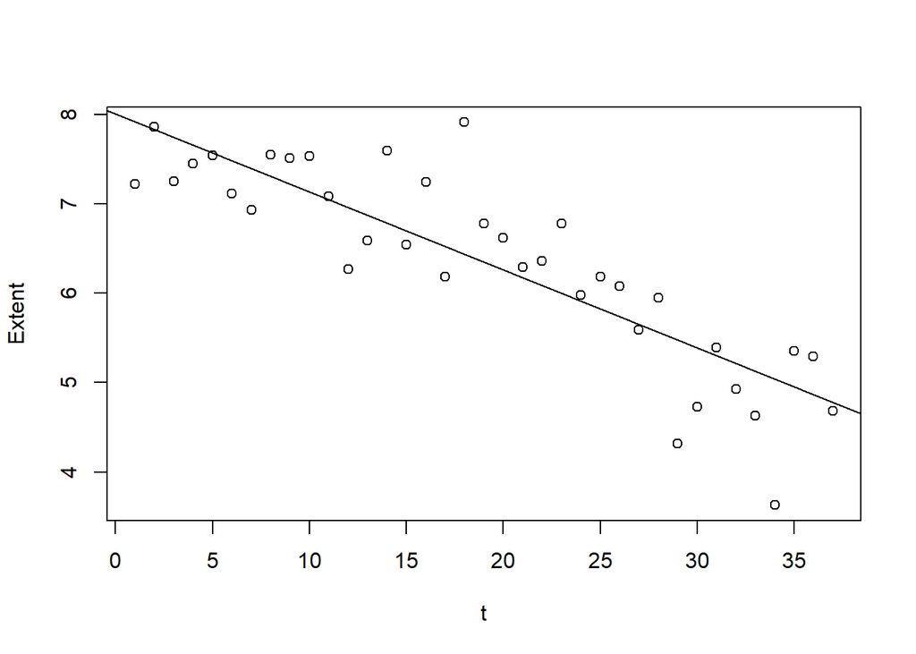

```r
View(SeaIce)
plot(Extent~t, data = SeaIce)
IceModel=lm(Extent~t, data = SeaIce)
abline(IceModel)
```

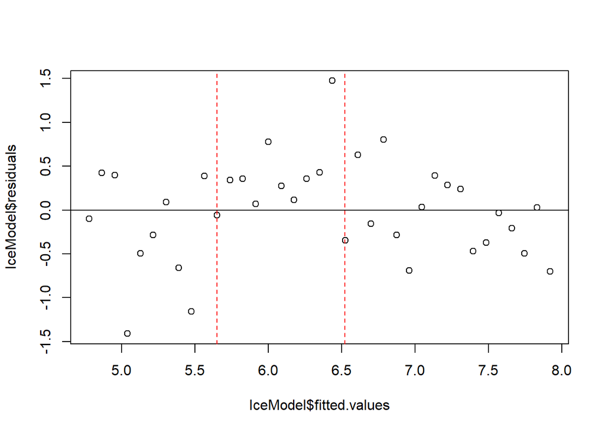

```r
plot(IceModel$residuals~IceModel$fitted.values)
abline(0,0)
abline(v=c(5.65,6.52), col=c("red", "red"), lty=c(2,2), lwd=c(1, 1)) #Draws red dashed vertical lines
```

In the plot of Extent versus t (time), a linear model appears to be a useful fit to describe the relationship between the variables. Upon further inspection of the residuals vs fitted values, you can see that for values in the middle range of fitted values (between the red lines), there are no negative residuals. This denotes that there may be a curve to the trend in data.

Apply a transformation to the data, and make a new linear model with this transformed data that is a better fit for the data (and no longer has the above issue in the residuals)

**Possible tranformations include taking the log of one or both variables, or raising one variable to a power (a^b).**

Include a plot of the transformed data with your new linear model and a plot of the residuals vs fitted values. You do not need to plot the original data with the curved, nonlinear model. Briefly explain why this transformation provides a better fit for a linear model.

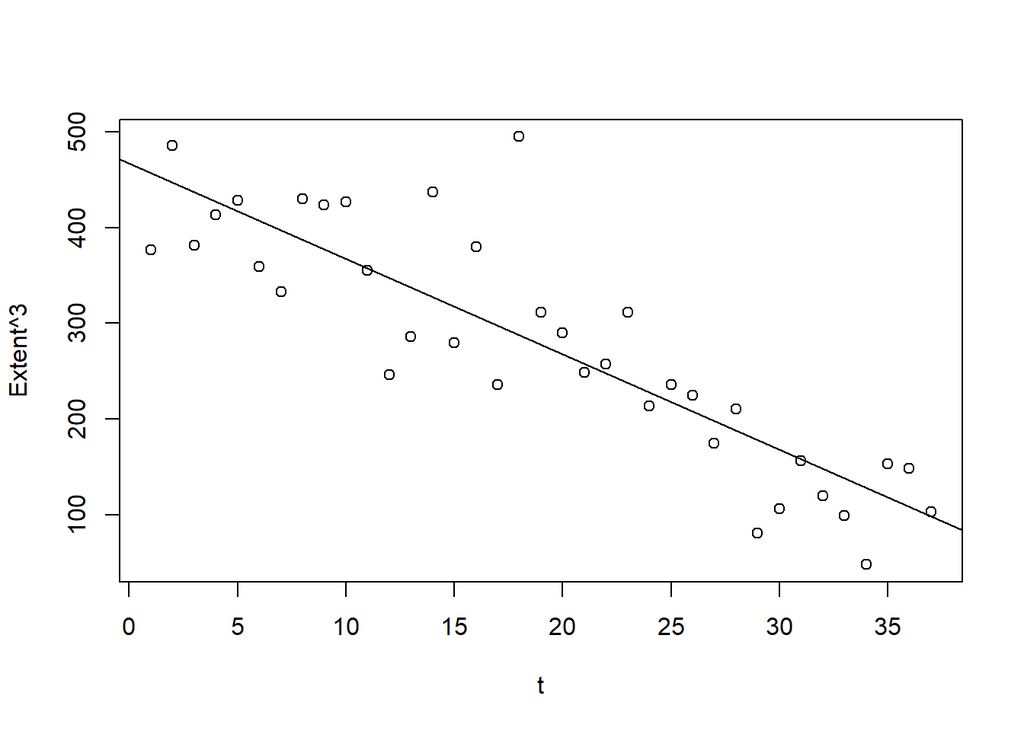

```r
plot(Extent^3 ~ t, data = SeaIce)
IceModelnew=lm(Extent^3 ~ t, data = SeaIce)
abline(IceModelnew)
```

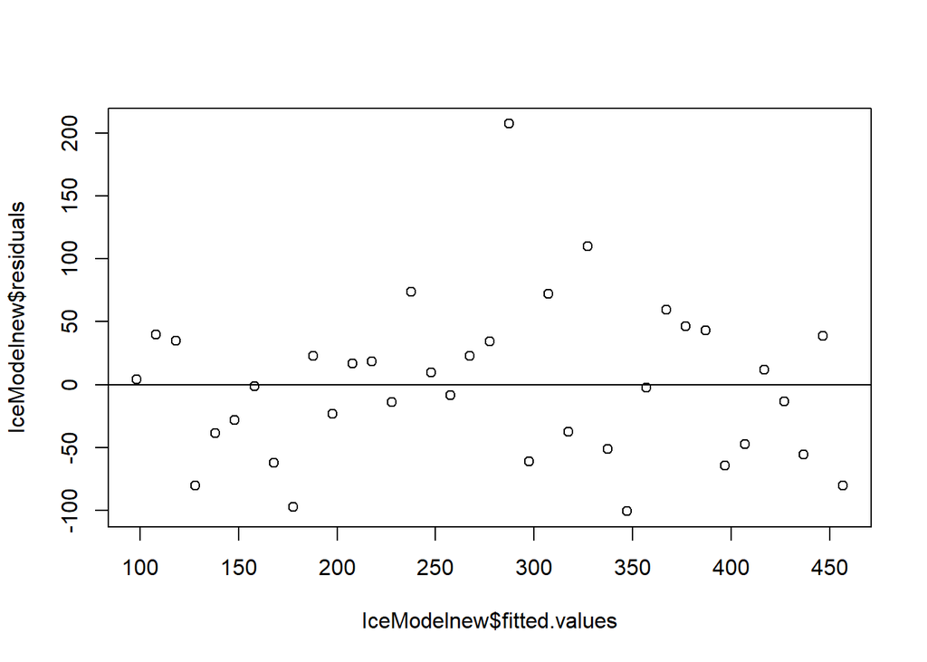

```r
plot(IceModelnew$residuals~IceModelnew$fitted.values)
abline(0,0)
```

***

Raising extent to the 3rd power accounts where there is a slight curve to the data. As you can see in the plot of the residuals versus the fitted values, the issue of no negative residuals for that range is gone, showing zero mean, (the distribution of errors is centered at zero)